# moodleQ-man-[ENG]

[figure not shown]

**Miguel A. Castellanos** and **José C. Chacón**

mcastellanos@psi.ucm.es  
jchacon@psi.ucm.es

Universidad Complutense de Madrid

**moodleQ** is an R package for the creation of question banks for moodle from a perspective based on R6 classes and Object Oriented Programming (OOP).

## Table of Contents

1. Objectives
2. Installation and first steps
3. Using R6 classes
4. Types of questions
5. Using Formatted Text
6. Insert files in the questionnaire
7. Create answer banks
8. Example 1: Reading multiple choice questions from a file
9. Example 2: Building a test with a common statement
10. Example 3: Downloading a file with data
- Download this documentation in pdf and with sample code: moodleQ-man.zip
- Go to github page: mcstllns/moodleQ

## Objetives

MoodelQ is an R library that allows you to easily create questions of the main types that moodle has. The questions are saved in an xml file that is imported in moodle into your question bank. This system is much faster than creating questions one by one using moodle’s graphical interface and allows you to design more complex questionnaires. This document explains with examples how to use the library. To learn about moodle, its question bank and its xml format, please refer to the following pages:

- About moodle: moodle.org | [About moodle](https://docs.moodle.org/38/en/About_Moodle)
- The moodle question bank: [Question bank](https://docs.moodle.org/38/en/Question_bank)
- The moodle xml format: Moodle_XML_format
- How to have a local installation of moodle with docker: [bitnami/moodle](https://hub.docker.com/r/bitnami/moodle/)

This package is in a very preliminary phase (v0.5.3) so it must be used with care and it is recalled that it has no guarantee on its operation.

An example, to create a multiple choice question:

```r
q1 <- question$new(
  type="multichoice",
  'name' = "Q001",
  'question' = "This is the question text",
  'answer' = list("Answer #1", 100),
  'answer' = list("Answer #2"),
  'answer' = list("Answer #3"))

Q <- quiz$new(q1)
Q$save_xml("myfile.xml")
```

The code above generates a multiple choice question with three alternatives (the first one is the correct one, 100) which is saved in the file “myfile.xml” that can be imported into moodle’s question bank. It would generate the following moodle question

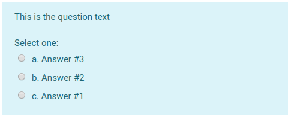

## Installation and first steps

The package can be installed via devtools and github

```r
devtools::install_github("mcstllns/moodleQ")
```

If not already installed, devtools can be installed with

```r
install.packages("devtools")
```

and once the package is installed it is loaded with

```r
library(moodleQ)
```

Questions are created by invoking the constructor *question$new()*. The function arguments are the parameters that define a question. Each question type has defined default parameters or fields that must be filled in for it to be a valid question. Many of these parameters have been defined by default, although they can be modified (see the default settings at the end of this document); for example, the *single*, *shuffleanswer* and *answernumbering* arguments can be modified to change the way the question’s alternatives are marked, randomized and numbered, respectively.

```r
q1 <- question$new(
  type="multichoice",
  'name' = "Q001",
  'question' = "This is the question text",
  'single' = 'false',
  'shuffleanswers' = 0,
  'answernumbering' = 'none',
  'answer' = list("Answer #1", 100),
  'answer' = list("Answer #2"),
  'answer' = list("Answer #3"))
```

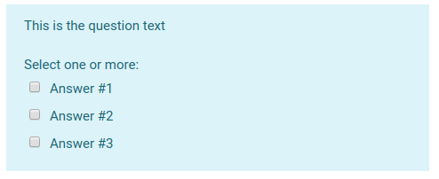

The types of moodle questions that are defined in moodleQ are as follows:

- multichoice
- truefalse
- shortanswer
- essay
- numerical
- description

The *matching* and *cloze* types of questions have not been implemented yet because they are absolutely useless for working with college students learning data analysis and data science disciplines

The following code creates two questions and stores them in a file: a *category* question (sets the category in which the questions in the file will be stored within the moodle bank) and a multiple choice question. The questions are packaged in a questionnaire called Q:

```r
q0 <- question$new(
  type="category",
  'name' = 'Q000',
  'category' = "$course$/test_moodleQ")

q1 <- question$new(
  type="multichoice",
  'name' = "Q001",
  'question' = "This is the question text",
  'answer' = list("Answer #1", 100),
  'answer' = list("Answer #2"),
  'answer' = list("Answer #3"))

Q <- quiz$new(q0, q1)
```

To see the content of a question, use the print() method or simply write the name of the object. To see the xml format of each question, the xml() method is used

```r
q0
```

```
##           props                 value
## 1   .attrs.type              category
## 2     name.text                  Q000
## 3 category.text $course$/test_moodleQ
```

```r
q0$xml()
```

```
## <question type="category">
##   <name>
##     <text>Q000</text>
##   </name>
##   <category>
##     <text>$course$/test_moodleQ</text>
##   </category>
## </question>
```

And to see the contents and the xml code of the whole questionnaire:

```r
Q
```

```
##
## nquestions:  2
##
## -----------
##           props                 value
## 1   .attrs.type              category
## 2     name.text                  Q000
## 3 category.text $course$/test_moodleQ
##
## -----------
##                       props                     value
## 1               .attrs.type               multichoice
## 2                 name.text                      Q001
## 3       questiontext.format                      html
## 4         questiontext.text This is the question text
```

[output cut: 25 more lines]

```r
Q$xml()
```

```
## <quiz>
##   <question type="category">
##     <name>
##       <text>Q000</text>
##     </name>
##     <category>
##       <text>$course$/test_moodleQ</text>
##     </category>
##   </question>
##   <question type="multichoice">
##     <name>
##       <text>Q001</text>
##     </name>
##     <questiontext format="html">
##       <text><![CDATA[This is the question text]]></text>
##     </questiontext>
##     <defaultgrade>1</defaultgrade>
##     <penalty>0</penalty>
##     <hidden>0</hidden>
##     <synchronize>2</synchronize>
##     <single>true</single>
##     <answernumbering>abc</answernumbering>
##     <shuffleanswers>1</shuffleanswers>
##     <unitgradingtype>0</unitgradingtype>
##     <unitpenalty>0.1</unitpenalty>
##     <showunits>3</showunits>
##     <unitsleft>0</unitsleft>
##     <format>html</format>
##     <answer fraction="100" format="html">
##       <text><![CDATA[Answer #1]]></text>
##     </answer>
##     <answer fraction="0" format="html">
##       <text><![CDATA[Answer #2]]></text>
##     </answer>
##     <answer fraction="0" format="html">
##       <text><![CDATA[Answer #3]]></text>
##     </answer>
##   </question>
## </quiz>
```

and save it in a file

```r
Q$save_xml("myfile.xml")
```

Once the file is created it can be imported into moodle as a question bank to build a questionnaire with them. Follow the instructions on this page ([Import Questions](https://docs.moodle.org/38/en/Import_questions)). In short, you can access the bank of questions from the course page by selecting **More**.

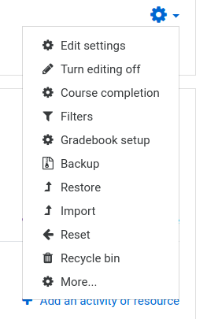

And then **Question Bank -> import**. In that page you select *Moodle XML format* and in the box *Import questions from file* you select the file created previously.

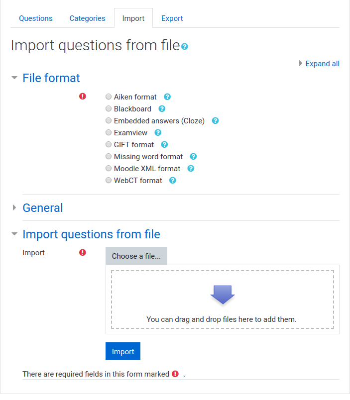

Once the questions have been imported, a new quiz will be created and questions will be added from the question bank. To see how to create quizzes you can go to https://docs.moodle.org/27/en/Building_Quiz

## Using R6 classes

moodleQ has been built with R6 classes, which gives it greater versatility in handling objects and methods than the libraries built with S3 and S4 classes. Its use is more reminiscent of the code of other object-oriented languages and has a somewhat more modern look. For example, the following syntax creates an object using the new() constructor.

```r
q1 <- question$new(
  type="multichoice",
  'name' = "Q001",
  'question' = "This is the question text",
  'answer' = list("Answer #1", 100),
  'answer' = list("Answer #2"),
  'answer' = list("Answer #3"))
```

But the following syntax in which the addanswer() method is applied in a chained way is equally valid. This possibility makes the writing of the code more flexible.

```r
q1 <- question$new(
  type="multichoice")

q1$set('name' = "Q001",
       'question' = "This is the question text")

q1$addanswer(list("Answer #1", 100))$
   addanswer(list("Answer #2"))$
   addanswer(list("Answer #3"))
```

A list of available methods can be seen in the package documentation

```r
help(package = "moodleQ")
```

And to learn more about the use of R6 classes, the following document is recommended: https://r6.r-lib.org/articles/Introduction.html

Using R6 can sometimes be confusing if you are used to the classic R form but it allows you to easily modify any object the way you want, which will be useful when working with questionnaires. The strategy of defining the whole question in the construction of the object or creating a simple skeleton to modify it will depend on the interests of the code.

## Types of questions

All question types accepted by moodle have been implemented (except *cloze* and *matching*). This section explains how to generate each of them together with the result obtained in moodle.

### category

It is not a question type, it only defines the category in which moodle will add what comes next. Usually it is the first one. The string *“$course$”* must be defined for moodle to properly place the questions with respect to the course root.

```r
q0 <- question$new(
  type="category",
  'name' = 'Q000',
  'category' = "$course$/test_moodleQ")
```

### multichoice

It is a question with alternatives (multiple choice question). It accepts many parameters but in its simplest format it requires a statement and at least two alternatives. The number of alternatives is variable.

```r
q1 <- question$new(
  type="multichoice",
  'name' = "Q001",
  'question' = "This is the question text",
  'answer' = list("Answer #1", 100),
  'answer' = list("Answer #2"),
  'answer' = list("Answer #3"))
```

Each alternative is defined as follows: text, punctuation, formatting:

- Text: required.
- Punctuation: by default equal to 0, at least one of the alternatives must have a value of 100.
- Format: by default the format defined in the *format* attribute is chosen.

To see all the options defined by default can be done:

```r
def_conf[['multichoice']]
```

```
##
## .attrs.type                multichoice
## name.text                         <NA>
## questiontext..attrs.format        html
## questiontext.text                 <NA>
## questiontext.text..cdata          TRUE
## defaultgrade                         1
## penalty                              0
## hidden                               0
## synchronize                          2
## single                            true
## answernumbering                    abc
## shuffleanswers                       1
## unitgradingtype                      0
## unitpenalty                        0.1
## showunits                            3
## unitsleft                            0
## format                            html
```

### description

It is not a question, just a statement or a text that is uploaded to the students. Of any length you want.

```r
q3 <- question$new(
  type="description",
  'name' = 'Q003',
  'question' = 'This is a very long question text explaining interesting things')
```

### truefalse

Questions in which only the options of true and false appear

```r
q5 <- question$new(
  type='truefalse',
  'name' = "P005",
  'question' = 'This is a question text for true/false questions',
  'answer' = list("true", 100),
  'answer' = list("false", 0),
)
```

One of the alternatives must be 100 and the other 0. Actually it is equivalent to multichoice but the values are defined as true and false and then moodle adapts it to the language of the installation (true and false in Spanish).

### shortanswer

These are questions with short alphanumeric answers that have to be adjusted to a defined answer. You can create as many as you need and each one can have a different score.

```r
q6 <- question$new(
  type="shortanswer",
  'name' = "P006",
  'question' = 'This is a question text for shortanswer questions',
  'answer' = list("This is the right answer", 100),
  'answer' = list("This is the ALMOST right answer", 90)
)
```

### numerical

Question with numerical solution answers. There may be several and with different success rates.

```r
q7 <- question$new(
  type="numerical",
  'name' = "P007",
  'question' = 'This is a question text for numerical questions',
  'answer' = list(17, 100)
)
```

The above questions, when included in a questionnaire, would generate the following document:

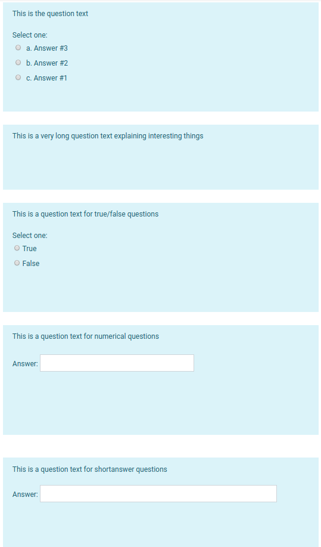

***